# Periodical Exam - 1 Indian Statistical Inst- Hyderabad

Certification program on Business Analytics

Sr. Mallesham Yamulla

*Below the answers have been given in for the problems 6 and 7*

**The below given necessary R packages have been made use of to build up statistical models**

```r
library(tidyverse)
library(ggplot2)
library(mosaic)
library(caret)
library(broom)
library(yardstick)
library(psych)
library(readxl)
library(ggdendro)
library(infer)
library(olsrr)
```

### Data Importing of both AutoPrice and Crusie Ship

```r
AutoPriceRating_isi <- read_xlsx("AutopriceRating_isi.xlsx")

Cruiseship_isi <- read_xlsx("Cruise_isi.xlsx")
```

### Data Wrangling

```r
# Keeping a side few variables and changing their type to factor

Cruiseship_isi <- Cruiseship_isi %>% mutate(Line=as.factor(Line))

AutoPriceRating_tidy <- AutoPriceRating_isi %>%
  select(-c(Sl.No, Make, `Body-style`, `Engine-type`, `Num-of-cylinders`, `Num-of-doors`, `Drive-wheels`,`Engine-location`, `Fuel-system`,`Curb-weight`,`Wheel-base`) ) %>%
mutate(`Performance  Rating`=as.factor(`Performance  Rating`),`Emission Standards`=as.factor(`Emission Standards`), `Fuel-Type` = as.factor(`Fuel-Type`), Aspiration=as.factor(Aspiration))

# very few missig values have been omitted
AutoPriceRating_tidy <- na.omit(AutoPriceRating_tidy)
Cruiseship_isi <- na.omit(Cruiseship_isi)
```

> The given data set contains the mix of coninuous, discrete and categorical variables, there are very few observations filled as NA’s, and these have been keept a side for the analysis, and Categorical variables were converted to a type of factor, in addition to it, few variables that leads to multicolinearity have been taken off as described in the above code.

### Glace at datasets

```r
# AutoPrices
knitr::kable(head(AutoPriceRating_tidy))
```

| Fuel-Type | Aspiration | Length | Width | Height | Engine-size | Bore | Stroke | Compression-ratio | Horsepower | Peak-rpm | City-mpg | Highway-mpg | Price | Emission Standards | Performance Rating |
| --- | --- | --- | --- | --- | --- | --- | --- | --- | --- | --- | --- | --- | --- | --- | --- |
| gas | std | 168.8 | 64.1 | 48.8 | 130 | 3.47 | 2.68 | 9.0 | 111 | 5000 | 21 | 27 | 13495 | Meeting | High |
| gas | std | 168.8 | 64.1 | 48.8 | 130 | 3.47 | 2.68 | 9.0 | 111 | 5000 | 21 | 27 | 16500 | Meeting | High |
| gas | std | 171.2 | 65.5 | 52.4 | 152 | 2.68 | 3.47 | 9.0 | 154 | 5000 | 19 | 26 | 16500 | Meeting | Medium |
| gas | std | 176.6 | 66.2 | 54.3 | 109 | 3.19 | 3.40 | 10.0 | 102 | 5500 | 24 | 30 | 13950 | Meeting | High |
| gas | std | 176.6 | 66.4 | 54.3 | 136 | 3.19 | 3.40 | 8.0 | 115 | 5500 | 18 | 22 | 17450 | Meeting | High |
| gas | std | 177.3 | 66.3 | 53.1 | 136 | 3.19 | 3.40 | 8.5 | 110 | 5500 | 19 | 25 | 15250 | Meeting | High |

```r
# CruiseShip
knitr::kable(head(Cruiseship_isi))
```

| Ship | Line | YearBlt | passngrs | Length | Cabins | Crew | PassSpcR | outcab | Tonnage |
| --- | --- | --- | --- | --- | --- | --- | --- | --- | --- |
| Journey | Azamara | 2007 | 694 | 594 | 355 | 355 | 42.64 | 329 | 30277 |
| Quest | Azamara | 2007 | 694 | 594 | 355 | 355 | 42.64 | 329 | 30277 |
| Celebration | Carnival | 1987 | 1486 | 722 | 743 | 670 | 31.80 | 453 | 47262 |
| Conquest | Carnival | 2002 | 2974 | 953 | 1488 | 1910 | 36.99 | 892 | 110000 |
| Destiny | Carnival | 1996 | 2642 | 892 | 1321 | 1000 | 38.36 | 740 | 101353 |
| Ecstasy | Carnival | 1991 | 2052 | 855 | 1020 | 920 | 34.29 | 618 | 70367 |

## Statistical Modelling on CruiseShip Data

```r
# Taking out unusuful variables
smallHELPCruise <- Cruiseship_isi %>% select(-c(1:2))

# Correlation
cor(smallHELPCruise)
```

```
##            YearBlt   passngrs      Length     Cabins       Crew
## YearBlt  1.0000000  0.5155423  0.53228589  0.5100190  0.5306565
## passngrs 0.5155423  1.0000000  0.88353479  0.9763414  0.9152341
## Length   0.5322859  0.8835348  1.00000000  0.8897982  0.8958566
## Cabins   0.5100190  0.9763414  0.88979821  1.0000000  0.9508226
## Crew     0.5306565  0.9152341  0.89585663  0.9508226  1.0000000
## PassSpcR 0.2788302 -0.2948671 -0.09048847 -0.2531807 -0.1555093
## outcab   0.5472031  0.9145506  0.90104699  0.9341361  0.9004656
## Tonnage  0.6066461  0.9450614  0.92236832  0.9487636  0.9275688
##             PassSpcR     outcab     Tonnage
## YearBlt   0.27883020  0.5472031  0.60664609
## passngrs -0.29486708  0.9145506  0.94506140
## Length   -0.09048847  0.9010470  0.92236832
## Cabins   -0.25318074  0.9341361  0.94876357
## Crew     -0.15550928  0.9004656  0.92756881
## PassSpcR  1.00000000 -0.1456023 -0.04084624
## outcab   -0.14560229  1.0000000  0.92193148
## Tonnage  -0.04084624  0.9219315  1.00000000
```

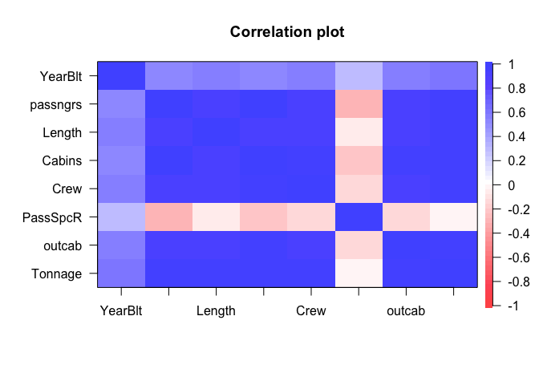

```r
# Correlation Map
cor.plot(Cruiseship_isi[-c(1:2)])
```

### Visualization and Data Analysis

*VIS 1: In which year the more ships built up?*

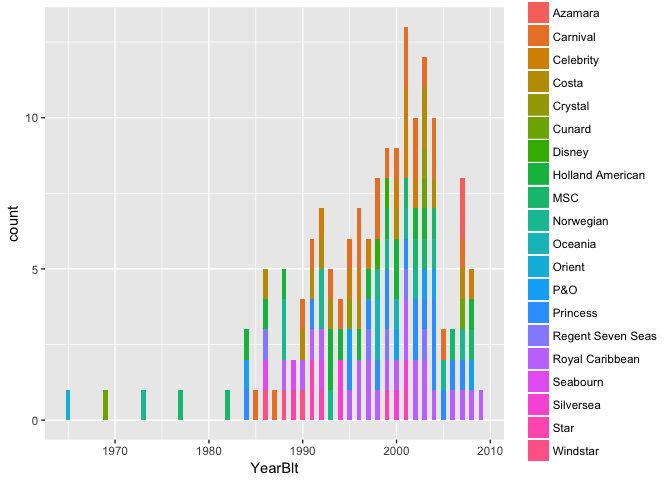

```r
ggplot(Cruiseship_isi, aes(YearBlt)) +  geom_bar(aes(fill=Line), width = 0.5)
```

> It is graphed that the ships were buit up more in the years between 2000-2005 and they have almost crossed over the major lines.

*VIS 2: How are the passenger counts in the newer ships?*

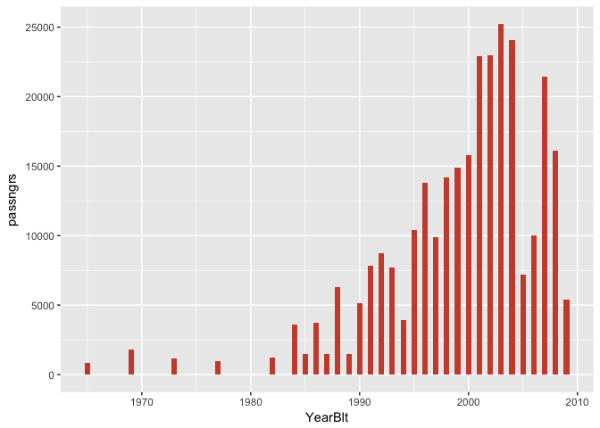

```r
ggplot(Cruiseship_isi, aes(x=YearBlt, y=passngrs)) +
  geom_bar(stat="identity", width=.5, fill="tomato3")
```

> The passengers are seen travelling more in the ships that were built up in the years between 2000-2008

*VIS 3: Through Which line the ships have travelled with more passengers?*

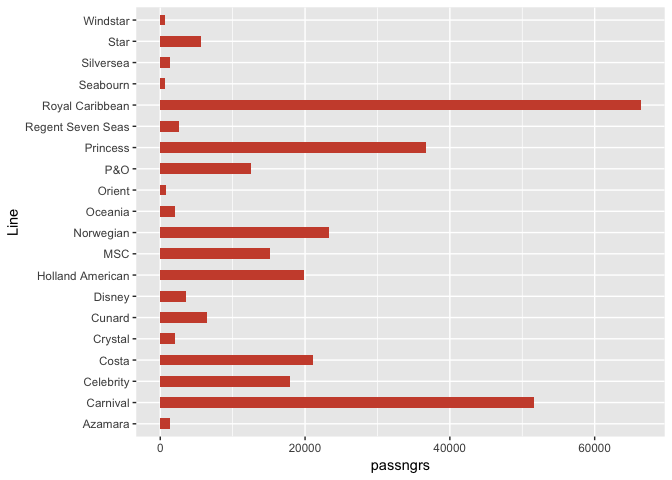

```r
ggplot(Cruiseship_isi, aes(x=Line, y=passngrs)) +
  geom_bar(stat="identity", width=.5, fill="tomato3") + coord_flip()
```

> The top 3 lines are found to be as Royal Caribean, Carninval and Princess.

*VIS 4: How much of tonnage a ship consist of over the different lines?*

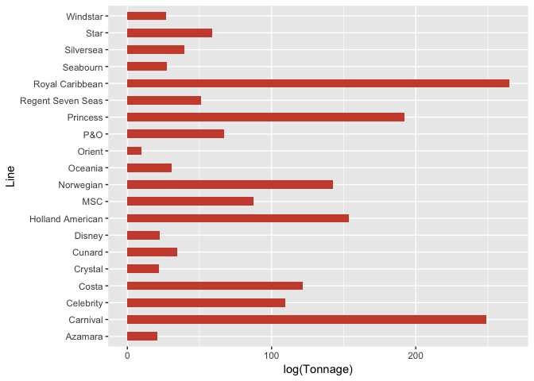

```r
ggplot(Cruiseship_isi, aes(x=Line, y=log(Tonnage))) +
  geom_bar(stat="identity", width=.5, fill="tomato3") + coord_flip()
```

*VIS 5: Is the passenger space getting changed as the ship length gets increased?*

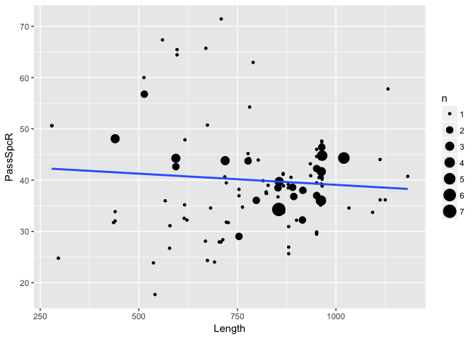

```r
ggplot(Cruiseship_isi,aes(Length,PassSpcR)) + geom_count() + geom_smooth(method="lm", se=F)
```

> It is seen that as length is getting changed it’s passenger spaces are getting changed.

*VIS 6: Is there any relationship between length and cabins of ships ?*

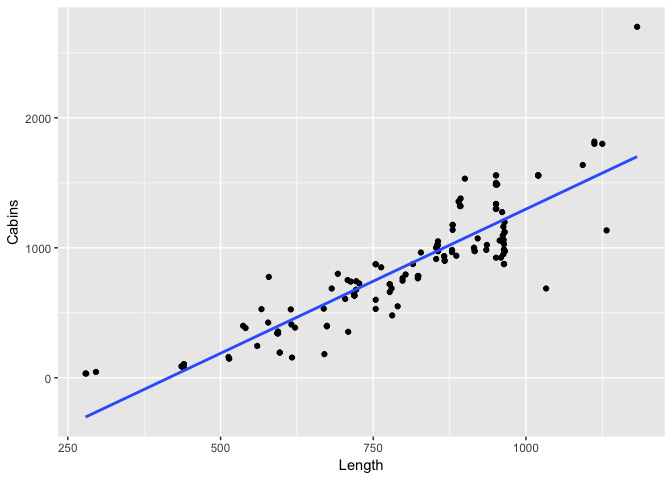

```r
ggplot(Cruiseship_isi, aes(Length, Cabins)) + geom_point() + geom_smooth(method="lm", se=F)
```

> The higher the length ships have the more cabins.

*VIS 7: How are the counts of passenger and Crew in the ships?*

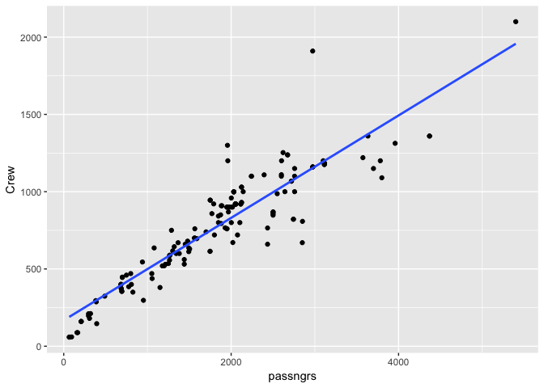

```r
ggplot(Cruiseship_isi, aes(passngrs, Crew)) + geom_point() + geom_smooth(method="lm", se=F)
```

> It is made out that the more crews are required when passengers are more.

### Carrying out Principle Component Analysis Technique

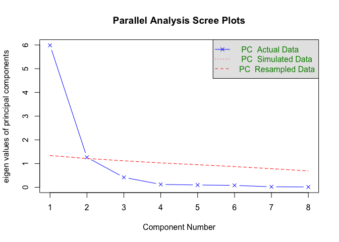

```
## Parallel analysis suggests that the number of factors =  NA  and the number of components =  2
```

```r
# Parallel analysis to determine how many component will be required

fa.parallel(Cruiseship_isi[,-c(1:2)],fa="pc", n.iter = 100)
```

```r
# Principal Components

pc_cruiseship <- principal(Cruiseship_isi[,-c(1:2)],nfactors = 2, rotate = "varimax", scores = TRUE)

pc_cruiseship
```

```
## Principal Components Analysis
## Call: principal(r = Cruiseship_isi[, -c(1:2)], nfactors = 2, rotate = "varimax",
##     scores = TRUE)
## Standardized loadings (pattern matrix) based upon correlation matrix
##            RC1   RC2   h2    u2 com
## YearBlt   0.59  0.61 0.72 0.275 2.0
## passngrs  0.98 -0.11 0.96 0.036 1.0
## Length    0.94  0.07 0.89 0.112 1.0
## Cabins    0.98 -0.08 0.97 0.027 1.0
## Crew      0.96  0.01 0.92 0.078 1.0
## PassSpcR -0.20  0.92 0.89 0.107 1.1
## outcab    0.96  0.02 0.92 0.082 1.0
## Tonnage   0.97  0.13 0.96 0.038 1.0
##
##                        RC1  RC2
## SS loadings           5.97 1.27
## Proportion Var        0.75 0.16
## Cumulative Var        0.75 0.91
## Proportion Explained  0.82 0.18
## Cumulative Proportion 0.82 1.00
##
## Mean item complexity =  1.1
## Test of the hypothesis that 2 components are sufficient.
##
## The root mean square of the residuals (RMSR) is  0.04
##  with the empirical chi square  14.38  with prob <  0.35
##
## Fit based upon off diagonal values = 1
```

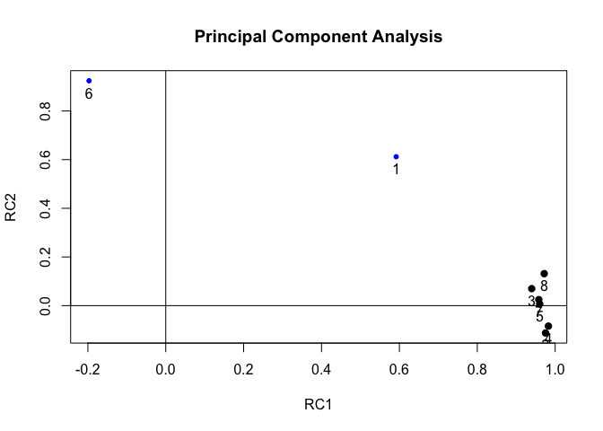

```r
# PCA Visualization

plot.psych(pc_cruiseship)
```

```r
# How are varaibles correlated?

cor(Cruiseship_isi$Length,pc_cruiseship$scores)
```

```
##            RC1        RC2
## [1,] 0.9397714 0.06988624
```

*Interpretation:*

> The column labeled RC1, and RC2 contains the component loadings which are correlations of the observed variables with in principle component

> The column labeled h2 contains the component communalities- the amount of variance in each variable explained by the components

> The column labeled u2 contains the component uniqueness - the amount of variance not accounted by the components

> The row labeled SS loadings contains the eighenvalues associated with the components, the eighen values are the standardized variance associated with a particular component

> The row labeled Proportion Var represents the amount of variance accounted for by each component

> The first component accounts for 75 % of the variance in the Cruiseship data,where as the second component accounts for 16%

> Together the two components accounts for 91% of the variance.

### Applying Linear Regression modelling on CruiseShip

```r
# Split the data into training and test sets
set.seed(1234)

# Shuffle the dataset, call the result shuffled
n <- nrow(Cruiseship_isi)
shuffled <- Cruiseship_isi[sample(n),]

# Split the data in train and test
train_cruise <- shuffled[1:round(0.8 * n),]
test_cruise <- shuffled[(round(0.8 * n) + 1):n,]
```

```r
# Model filtting
fit_lm_Cruise <- train(Tonnage ~ ., method = "lm", data = train_cruise[,-c(1:2)],
                trControl = trainControl(method = "none"))

# Model Sumamry
summary(fit_lm_Cruise)
```

```
##
## Call:
## lm(formula = .outcome ~ ., data = dat)
##
## Residuals:
##      Min       1Q   Median       3Q      Max
## -16764.0  -3227.7    -70.7   2635.0  31356.9
##
## Coefficients:
##               Estimate Std. Error t value Pr(>|t|)
## (Intercept) -2.672e+05  2.321e+05  -1.151 0.252083
## YearBlt      1.078e+02  1.177e+02   0.915 0.361826
## passngrs     1.978e+01  3.078e+00   6.426 2.89e-09 ***
## Length       3.580e+01  9.108e+00   3.930 0.000143 ***
## Cabins       2.387e+01  8.994e+00   2.654 0.009055 **
## Crew         5.701e+00  7.393e+00   0.771 0.442143
## PassSpcR     8.167e+02  9.012e+01   9.062 3.30e-15 ***
## outcab      -6.852e-01  6.225e+00  -0.110 0.912535
## ---
## Signif. codes:  0 '***' 0.001 '**' 0.01 '*' 0.05 '.' 0.1 ' ' 1
##
## Residual standard error: 6701 on 118 degrees of freedom
## Multiple R-squared:  0.9711, Adjusted R-squared:  0.9694
## F-statistic: 566.4 on 7 and 118 DF,  p-value: < 2.2e-16
```

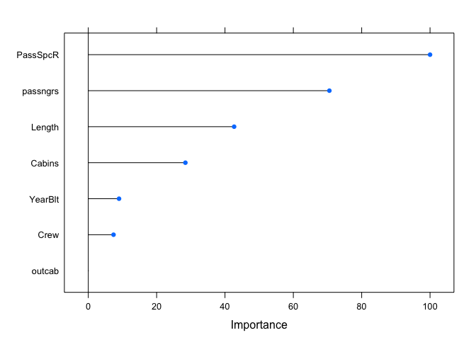

```r
# Visualization
imp_var_cruise <- varImp(fit_lm_Cruise)

plot(imp_var_cruise)
```

*Interpretation:*

> The Tonange seems to be a highly significant. The $R^2$ suggests that the model explains 97% of the variability of the response variable ‘Tonnage’ of a ship

### Applying Unsupervised K-means algorithm

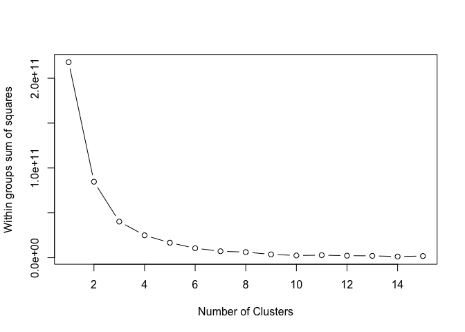

```r
# Initialize total within sum of squares error: wss
wss <- 0

# Look over 1 to 15 possible clusters
for (i in 1:15) {
  # Fit the model: km.out
  km.out <- kmeans(Cruiseship_isi[,-c(1:2)], centers = i, nstart = 20, iter.max = 50)
  # Save the within cluster sum of squares
  wss[i] <- km.out$tot.withinss
}



# Produce a scree plot
plot(1:15, wss, type = "b",
     xlab = "Number of Clusters",
     ylab = "Within groups sum of squares")
```

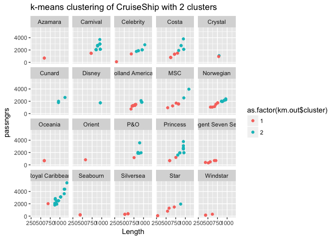

```r
# Select number of clusters (2, 3, 4 probably OK)
k <- 2


# Build model with k clusters: km.out
km.out <- kmeans(Cruiseship_isi[-c(1:2)], centers = k, nstart = 20, iter.max = 50)

ggplot(Cruiseship_isi,aes(Length,passngrs,col=as.factor(km.out$cluster))) + geom_point() + facet_wrap(~Line) +labs(title="k-means clustering of CruiseShip with 2 clusters")
```

## Statistical Modelling on AutoPrice and Rating Data

### Data Visualization and Analysis

*VIS 1 : How the avg HorsePower of Car over the 2 differnt fuel type of a car?*

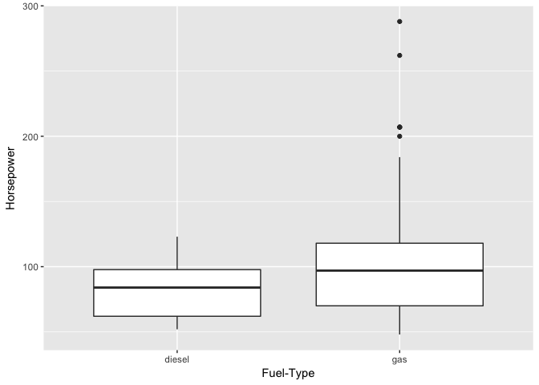

```r
ggplot(AutoPriceRating_isi,aes(`Fuel-Type`, Horsepower )) + geom_boxplot()
```

> The Avg Horsepower seems to be more in car which are running with fuel type gas than the diesel cars.

*VIS 2 : Which Car manufactures have got good performance rating from their customers?*

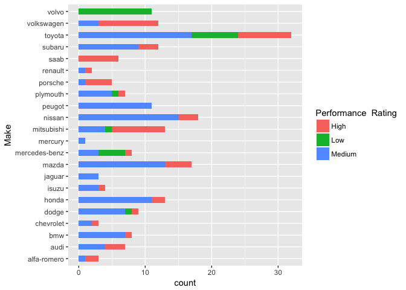

```r
ggplot(AutoPriceRating_isi,aes(Make)) + geom_bar(aes(fill=`Performance  Rating`), width = 0.5) + coord_flip()
```

*VIS 3 : How is the City Mpg in the cars which have different no.of cylinders?*

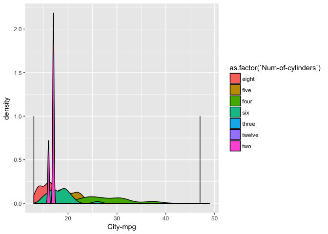

```r
ggplot(AutoPriceRating_isi, aes(`City-mpg`)) + geom_density(aes(fill=as.factor(`Num-of-cylinders`)))
```

*VIS 4 : How is the Highway Mpg in the cars which have different no.of cylinders?*

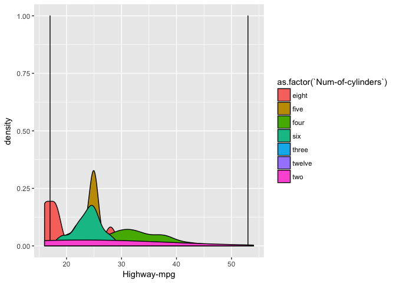

```r
ggplot(AutoPriceRating_isi, aes(`Highway-mpg`)) + geom_density(aes(fill=as.factor(`Num-of-cylinders`)))
```

*VIS 5 : In which type of car engines the avg horsepower is recorded more?*

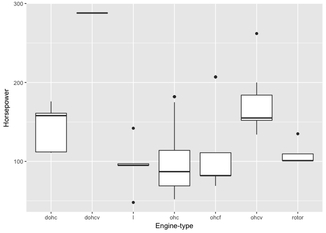

```r
ggplot(AutoPriceRating_isi,aes(`Engine-type`,Horsepower)) + geom_boxplot()
```

### Formulation Hypothesis on Cars data

##### CASE 1:

*Null hypothesis:* **The avg. Highway Mpg of a vehicle is the same for RATIO AND TURBO vehicles**

*Alternate hypothesis:* **The avg. Highway Mpg of Turbo vechicle is higher than the RATIO ones**

```r
Auto_hyp1 <- AutoPriceRating_isi %>% select(Aspiration,`Highway-mpg`) %>% mutate(Aspiration=factor(Aspiration))

#Generate 1000 differences in means via randomization

null_distribution_auto_model <- Auto_hyp1 %>%
  specify(`Highway-mpg` ~ Aspiration) %>%
  hypothesize(null = "independence") %>%
  generate(reps = 1000, type = "permute") %>%
  calculate(stat = "diff in means", order = c("std", "turbo"))

#  Calulcate diff in observed means
obs_stat_auto_model <- Auto_hyp1  %>%
  group_by(Aspiration) %>%
  summarize(mean = mean(`Highway-mpg`)) %>%
  summarize(obs_stat = diff(mean)) %>%
  pull(obs_stat)

# P value

null_distribution_auto_model %>%
  filter(stat>obs_stat_auto_model) %>%
  summarize(p_val = n() / 1000) %>%
  pull()
```

```
## [1] 1
```

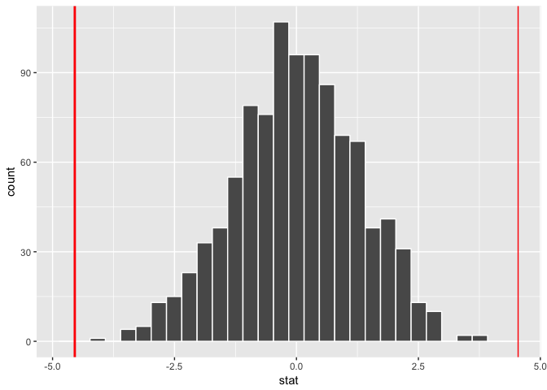

```r
# Visualization

plot_model <- null_distribution_auto_model %>%
  visualize()

plot_model + geom_vline(xintercept = obs_stat_auto_model, col = "red", size = 1) + geom_vline(color = "red", xintercept = -obs_stat_auto_model)
```

> P value caluclated is greater than significance level 0.05, hence we fail to reject the null hypothesis.

##### CASE 2:

*Null hypothesis:* **The avg city mpg is the same across all the cylinders type cars**

*Alternate hypothesis:* **The avg city mpg of a differs between at least one pair of cylinder**

```r
# Transformation

Auto_hyp2 <- AutoPriceRating_isi %>% select(`Num-of-cylinders`, `City-mpg`) %>% mutate(`Num-of-cylinders`=as.factor(`Num-of-cylinders`))

# Applyting anova

Auto_aov <- aov(`City-mpg` ~ `Num-of-cylinders`, data=Auto_hyp2) %>% tidy()

SST <- Auto_aov[[1,3]] + Auto_aov[[2,3]]

Auto_aov_percentage_of_explained_var <- Auto_aov[[1,3]] / SST

# Summary

print(Auto_aov)
```

```
##                 term  df    sumsq   meansq statistic      p.value
## 1 `Num-of-cylinders`   6 3472.757 578.7928  21.79403 1.299979e-19
## 2          Residuals 198 5258.365  26.5574        NA           NA
```

```r
print(Auto_aov_percentage_of_explained_var)
```

```
## [1] 0.3977446
```

### General Linear Model and Generalized Linear Models - Supervised Learning.

```r
# Splitting data into Train and Test datasets

# Split the data into training and test sets
set.seed(1234)

# Shuffle the dataset, call the result shuffled
n <- nrow(AutoPriceRating_tidy)
shuffled <- AutoPriceRating_tidy[sample(n),]

training_cars <- shuffled[1:round(0.8 * n),]
testing_cars <- shuffled[(round(0.8 * n) + 1):n,]

#training_cars <- na.omit(training_cars)
```

### Applying Linear Regression Models

#### CASE 1: Stepwise Selection with k Cross folds

```r
# Model fitting
fit_lm_cars_ssc <-  train(Price ~ . , method = "lmStepAIC", data = training_cars, trControl = trainControl(method = "cv"))
```

```r
# Training data
# Create the new columns
results_tr_car_ssc <- training_cars %>%
    mutate(`Linear regression` = predict(fit_lm_cars_ssc, training_cars))

# Evaluate the performance
metrics(results_tr_car_ssc, truth = Price, estimate = `Linear regression`)
```

```
## # A tibble: 1 x 2
##    rmse   rsq
##   <dbl> <dbl>
## 1 3078. 0.850
```

```r
# Training data

# Create the new columns
results_te_car_ssc <- testing_cars %>%
    mutate(`Linear regression` = predict(fit_lm_cars_ssc, testing_cars))

# Evaluate the performance
metrics(results_tr_car_ssc, truth = Price, estimate = `Linear regression`)
```

```
## # A tibble: 1 x 2
##    rmse   rsq
##   <dbl> <dbl>
## 1 3078. 0.850
```

#### CASE 2: Stepwise Selection with LOOCV

```r
# Model fitting

fit_lm_cars_ssl <- train(Price ~ ., method = "lmStepAIC", data = training_cars, trControl = trainControl(method = "LOOCV"))
```

```r
# Training data

# Create the new columns
results_tr_car_ssl <- training_cars %>%
    mutate(`Linear regression` = predict(fit_lm_cars_ssl, training_cars))

# Evaluate the performance
metrics(results_tr_car_ssl, truth = Price, estimate = `Linear regression`)
```

[output not shown]

```r
# Testing data

# Create the new columns
results_te_car_ssl <- testing_cars %>%
    mutate(`Linear regression` = predict(fit_lm_cars_ssl, testing_cars))

# Evaluate the performance
metrics(results_tr_car_ssl, truth = Price, estimate = `Linear regression`)
```

[output not shown]